# Chapter 7 Time Series Linear Models

Tyler George

Cornell College  
STA 364 Spring 2025 Block 5

## Setup

```r
library(fpp3)
```

## Multiple regression and forecasting

$$y_t = \beta_0 + \beta_1 x_{1,t} + \beta_2 x_{2,t} + \cdots + \beta_kx_{k,t} + \varepsilon_t.$$

- $y_t$ is the variable we want to predict: the “response” variable
- Each $x_{j,t}$ is numerical and is called a “predictor”. They are usually assumed to be known for all past and future times.
- The coefficients $\beta_1,\dots,\beta_k$ measure the effect of each predictor after taking account of the effect of all other predictors in the model.

- $\varepsilon_t$ is a white noise error term

## Example: US consumption expenditure

```r
us_change |> autoplot(Consumption) +
  geom_line(aes(y = Income, color = "Income")) +
  geom_line(aes(y = Consumption, color = "Consumption")) +
  scale_color_manual(values = c("Income" = "blue", "Consumption" = "red")) +
  labs(y = "% change", color = "Legend")
```

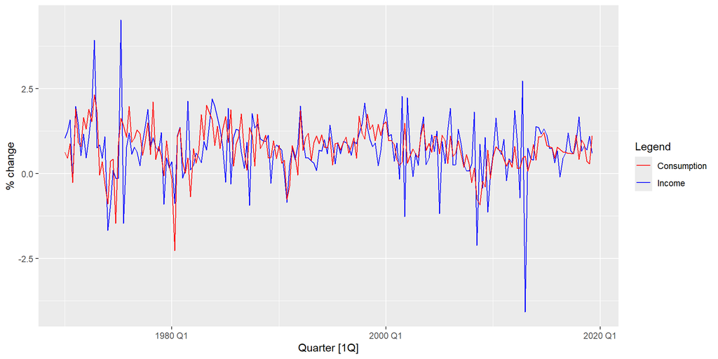

## Example: US consumption expenditure

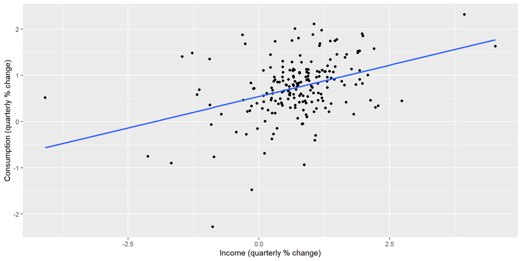

```r
us_change |> ggplot(aes(x=Income, y=Consumption)) +
  labs(y = "Consumption (quarterly % change)",
       x = "Income (quarterly % change)") +
  geom_point() + geom_smooth(method="lm", se=FALSE)
```

## Example: US consumption expenditure

```r
fit_cons <- us_change |>
  model(lm = TSLM(Consumption ~ Income))
report(fit_cons)
```

```
Series: Consumption
Model: TSLM

Residuals:
     Min       1Q   Median       3Q      Max
-2.58236 -0.27777  0.01862  0.32330  1.42229

Coefficients:
            Estimate Std. Error t value Pr(>|t|)
(Intercept)  0.54454    0.05403  10.079  < 2e-16 ***
Income       0.27183    0.04673   5.817  2.4e-08 ***
---
Signif. codes:  0 '***' 0.001 '**' 0.01 '*' 0.05 '.' 0.1 ' ' 1

Residual standard error: 0.5905 on 196 degrees of freedom
Multiple R-squared: 0.1472, Adjusted R-squared: 0.1429
F-statistic: 33.84 on 1 and 196 DF, p-value: 2.4022e-08
```

## Example: US consumption expenditure

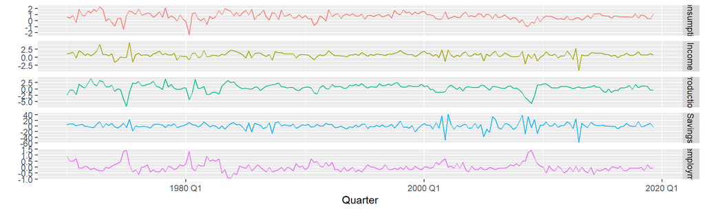

```r
us_change |>
  gather("Measure", "Change", Consumption, Income, Production, Savings, Unemployment) |>
  ggplot(aes(x = Quarter, y = Change, colour = Measure)) +
  geom_line() +
  facet_grid(vars(Measure), scales = "free_y") +
  labs(y = "") +
  guides(colour = "none")
```

## Example: US consumption expenditure

```r
us_change |>
  as_tibble() |>
  select(-Quarter) |>
  GGally::ggpairs()
```

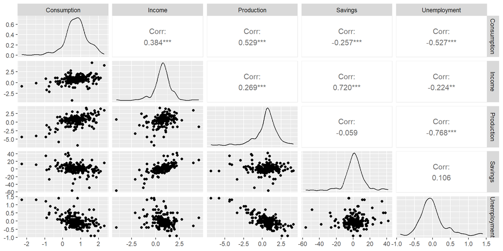

## Assumptions for the linear model

For forecasting purposes, we require the following assumptions:

- $\varepsilon_t$ have mean zero and are uncorrelated.
- $\varepsilon_t$ are uncorrelated with each $x_{j,t}$.

It is *useful* to also have $\varepsilon_t \sim \text{N}(0,\sigma^2)$ when producing prediction intervals or doing statistical tests.

## Least squares estimation

- In practice we need to estimate the coefficients: $\beta_0,\beta_1, \dots, \beta_k$.

$$\sum_{t=1}^T \varepsilon_t^2 = \sum_{t=1}^T (y_t -
\beta_{0} - \beta_{1} x_{1,t} - \beta_{2} x_{2,t} - \cdots - \beta_{k} x_{k,t})^2$$

`model(TSLM(y ~ x_1 + x_2 + ... + x_k))`

- Estimated coefficients: $\hat\beta_0, \dots, \hat\beta_k$

## Example: US consumption expenditure

```r
fit_consMR <- us_change |>
  model(lm = TSLM(Consumption ~ Income + Production + Unemployment + Savings))
report(fit_consMR)
```

```
Series: Consumption
Model: TSLM

Residuals:
     Min       1Q   Median       3Q      Max
-0.90555 -0.15821 -0.03608  0.13618  1.15471

Coefficients:
              Estimate Std. Error t value Pr(>|t|)
(Intercept)   0.253105   0.034470   7.343 5.71e-12 ***
Income        0.740583   0.040115  18.461  < 2e-16 ***
Production    0.047173   0.023142   2.038   0.0429 *
Unemployment -0.174685   0.095511  -1.829   0.0689 .
Savings      -0.052890   0.002924 -18.088  < 2e-16 ***
---
Signif. codes:  0 '***' 0.001 '**' 0.01 '*' 0.05 '.' 0.1 ' ' 1

Residual standard error: 0.3102 on 193 degrees of freedom
Multiple R-squared: 0.7683, Adjusted R-squared: 0.7635
F-statistic:   160 on 4 and 193 DF, p-value: < 2.22e-16
```

## Fitted values

$$\hat{y}_t = \hat\beta_{0} + \hat\beta_{1} x_{1,t} + \hat\beta_{2} x_{2,t} + \cdots + \hat\beta_{k} x_{k,t}$$

- Code
- Plot

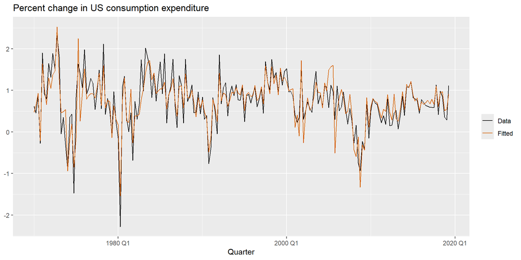

```r
augment(fit_consMR) |>
  ggplot(aes(x = Quarter)) +
  geom_line(aes(y = Consumption, colour = "Data")) +
  geom_line(aes(y = .fitted, colour = "Fitted")) +
  labs(y = NULL, title = "Percent change in US consumption expenditure") +
  scale_colour_manual(values = c(Data = "black", Fitted = "#D55E00")) +
  guides(colour = guide_legend(title = NULL))
```

## Example: US consumption expenditure

- Code
- Plot

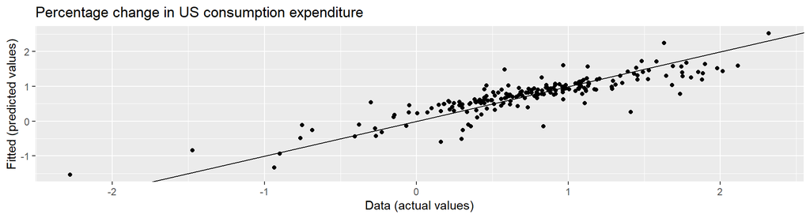

```r
augment(fit_consMR) |>
  ggplot(aes(y = .fitted, x = Consumption)) +
  geom_point() +
  labs(
    y = "Fitted (predicted values)",
    x = "Data (actual values)",
    title = "Percentage change in US consumption expenditure"
  ) +
  geom_abline(intercept = 0, slope = 1)
```

## Goodness of fit

**Coefficient of determination**

$$R^2 = \frac{\sum(\hat{y}_{t} - \bar{y})^2}{\sum(y_{t}-\bar{y})^2}$$

**Standard error of the regression**

$$\hat{\sigma}_e=\sqrt{\frac{1}{T-k-1}\sum_{t=1}^{T}{e_t^2}}$$

where $k$ is the number of predictors in the model.

## Multiple regression and forecasting

For forecasting purposes, we require the following assumptions:

- $\varepsilon_t$ are uncorrelated and zero mean
- $\varepsilon_t$ are uncorrelated with each $x_{j,t}$.

It is **useful** to also have $\varepsilon_t \sim \text{N}(0,\sigma^2)$ when producing prediction intervals or doing statistical tests.

## Residual plots

Useful for spotting outliers and whether the linear model was appropriate.

- Scatterplot of residuals $\varepsilon_t$ against each predictor $x_{j,t}$.
- Scatterplot residuals against the fitted values $\hat y_t$
- Expect to see scatterplots resembling a horizontal band with no values too far from the band and no patterns such as curvature or increasing spread.

## Residual patterns

- If a plot of the residuals vs any predictor in the model shows a pattern, then the relationship is nonlinear.
- If a plot of the residuals vs any predictor **not** in the model shows a pattern, then the predictor should be added to the model.
- If a plot of the residuals vs fitted values shows a pattern, then there is heteroscedasticity in the errors. (Could try a transformation.)

## Trend

**Linear trend**

$$x_t = t$$

- $t=1,2,\dots,T$
- Strong assumption that trend will continue.

## Dummy variables

If a categorical variable takes only two values (e.g., `Yes`, or `No`), then an equivalent numerical variable can be constructed taking value 1 if yes and 0 if no. This is called a *dummy variable*.

| Variable | dummy |
| --- | --- |
| Yes | 1 |
| Yes | 1 |
| No | 0 |
| Yes | 1 |
| No | 0 |
| No | 0 |
| Yes | 1 |
| Yes | 1 |
| No | 0 |
| No | 0 |

## Dummy variables

If there are more than two categories, then the variable can be coded using several dummy variables (one fewer than the total number of categories).

| Day | d1 | d2 | d3 | d4 |
| --- | --- | --- | --- | --- |
| Monday | 1 | 0 | 0 | 0 |
| Tuesday | 0 | 1 | 0 | 0 |
| Wednesday | 0 | 0 | 1 | 0 |
| Thursday | 0 | 0 | 0 | 1 |
| Friday | 0 | 0 | 0 | 0 |
| Monday | 1 | 0 | 0 | 0 |
| Tuesday | 0 | 1 | 0 | 0 |
| Wednesday | 0 | 0 | 1 | 0 |
| Thursday | 0 | 0 | 0 | 1 |
| Friday | 0 | 0 | 0 | 0 |

## Beware of the dummy variable trap!

- Using one dummy for each category gives too many dummy variables!
- The regression will then be singular and inestimable.
- Either omit the constant, or omit the dummy for one category.
- The coefficients of the dummies are relative to the omitted category.

## Uses of dummy variables

**Seasonal dummies**

- For quarterly data: use 3 dummies
- For monthly data: use 11 dummies
- For daily data: use 6 dummies
- What to do with weekly data?

**Outliers**

- If there is an outlier, you can use a dummy variable to remove its effect.

**Public holidays**

- For daily data: if it is a public holiday, dummy=1, otherwise dummy=0.

## Beer production revisited (1/6)

```r
recent_production <- aus_production |> filter(year(Quarter) >= 1992)
recent_production |> autoplot(Beer) +
  labs(y = "Megalitres", title = "Australian quarterly beer production")
```

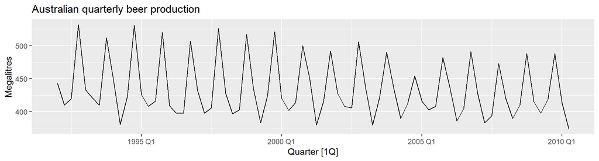

**Regression model**

$$y_t = \beta_0 + \beta_1 t + \beta_2d_{2,t} + \beta_3 d_{3,t} + \beta_4 d_{4,t} + \varepsilon_t$$

- $d_{i,t} = 1$ if $t$ is quarter $i$ and 0 otherwise.

## Beer production revisited (2/6)

```r
fit_beer <- recent_production |> model(TSLM(Beer ~ trend() + season()))
report(fit_beer)
```

```
Series: Beer
Model: TSLM

Residuals:
     Min       1Q   Median       3Q      Max
-42.9029  -7.5995  -0.4594   7.9908  21.7895

Coefficients:
               Estimate Std. Error t value Pr(>|t|)
(Intercept)   441.80044    3.73353 118.333  < 2e-16 ***
trend()        -0.34027    0.06657  -5.111 2.73e-06 ***
season()year2 -34.65973    3.96832  -8.734 9.10e-13 ***
season()year3 -17.82164    4.02249  -4.430 3.45e-05 ***
season()year4  72.79641    4.02305  18.095  < 2e-16 ***
---
Signif. codes:  0 '***' 0.001 '**' 0.01 '*' 0.05 '.' 0.1 ' ' 1

Residual standard error: 12.23 on 69 degrees of freedom
Multiple R-squared: 0.9243, Adjusted R-squared: 0.9199
F-statistic: 210.7 on 4 and 69 DF, p-value: < 2.22e-16
```

## Beer production revisited (3/6)

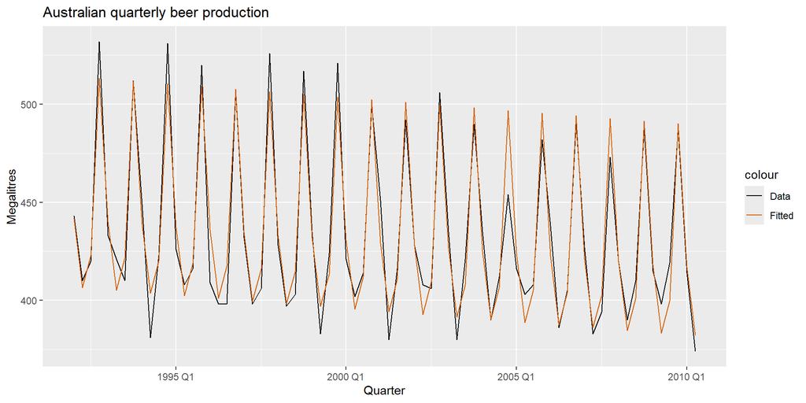

```r
augment(fit_beer) |>
  ggplot(aes(x = Quarter)) +
  geom_line(aes(y = Beer, colour = "Data")) +
  geom_line(aes(y = .fitted, colour = "Fitted")) +
  labs(y = "Megalitres", title = "Australian quarterly beer production") +
  scale_colour_manual(values = c(Data = "black", Fitted = "#D55E00"))
```

## Beer production revisited (4/6)

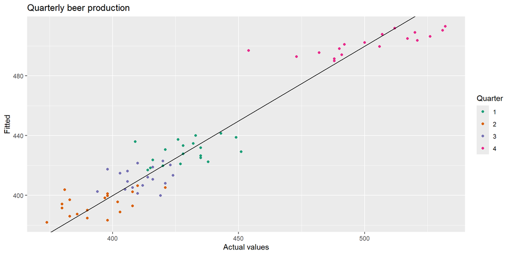

```r
augment(fit_beer) |>
  ggplot(aes(x = Beer, y = .fitted, colour = factor(quarter(Quarter)))) +
  geom_point() +
  labs(y = "Fitted", x = "Actual values", title = "Quarterly beer production") +
  scale_colour_brewer(palette = "Dark2", name = "Quarter") +
  geom_abline(intercept = 0, slope = 1)
```

## Beer production revisited (5/6)

```r
fit_beer |> gg_tsresiduals()
```

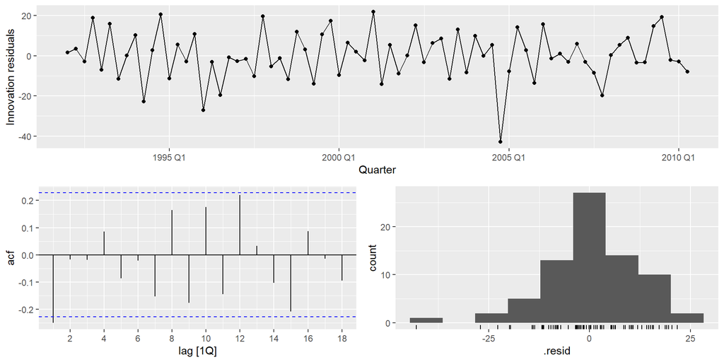

## Beer production revisited (6/6)

```r
fit_beer |>
  forecast() |>
  autoplot(recent_production)
```

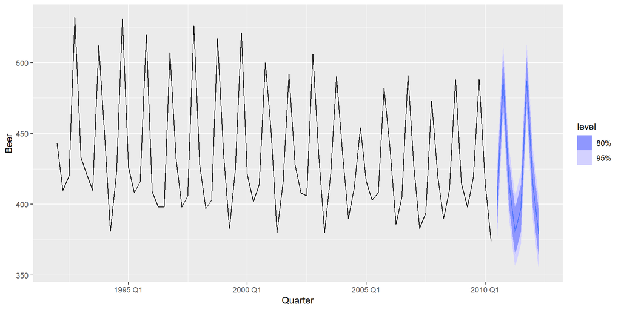

## Intervention variables

**Spikes**

- Equivalent to a dummy variable for handling an outlier.

**Steps**

- Variable takes value 0 before the intervention and 1 afterwards.

**Change of slope**

- Variables take values 0 before the intervention and values $\{1,2,3,\dots\}$ afterwards.

## Holidays

**For monthly data**

- Christmas: always in December so part of monthly seasonal effect
- Easter: use a dummy variable $v_t=1$ if any part of Easter is in that month, $v_t=0$ otherwise.
- Ramadan and Chinese new year similar.

## Distributed lags

Lagged values of a predictor.

Example: $x$ is advertising which has a delayed effect

$$\begin{align*}
x_{1} &= \text{advertising for previous month;} \\
x_{2} &= \text{advertising for two months previously;} \\
& \vdots \\
x_{m} &= \text{advertising for $m$ months previously.}
\end{align*}$$

## Fourier series

Periodic seasonality can be handled using pairs of Fourier terms:

$$s_{k}(t) = \sin\left(\frac{2\pi k t}{m}\right)\qquad c_{k}(t) = \cos\left(\frac{2\pi k t}{m}\right)$$

$$y_t = a + bt + \sum_{k=1}^K \left[\alpha_k s_k(t) + \beta_k c_k(t)\right] + \varepsilon_t$$
where $m$ is the seasonal period.

- Every periodic function can be approximated by sums of sin and cos terms for large enough $K$.
- Choose $K$ by minimizing AICc.
- Called “harmonic regression”

`TSLM(y ~ trend() + fourier(K))`

## Harmonic regression: beer production

```r
fourier_beer <- recent_production |> model(TSLM(Beer ~ trend() + fourier(K = 2)))
report(fourier_beer)
```

```
Series: Beer
Model: TSLM

Residuals:
     Min       1Q   Median       3Q      Max
-42.9029  -7.5995  -0.4594   7.9908  21.7895

Coefficients:
                    Estimate Std. Error t value Pr(>|t|)
(Intercept)        446.87920    2.87321 155.533  < 2e-16 ***
trend()             -0.34027    0.06657  -5.111 2.73e-06 ***
fourier(K = 2)C1_4   8.91082    2.01125   4.430 3.45e-05 ***
fourier(K = 2)S1_4 -53.72807    2.01125 -26.714  < 2e-16 ***
fourier(K = 2)C2_4 -13.98958    1.42256  -9.834 9.26e-15 ***
---
Signif. codes:  0 '***' 0.001 '**' 0.01 '*' 0.05 '.' 0.1 ' ' 1

Residual standard error: 12.23 on 69 degrees of freedom
Multiple R-squared: 0.9243, Adjusted R-squared: 0.9199
F-statistic: 210.7 on 4 and 69 DF, p-value: < 2.22e-16
```

## Harmonic regression: eating-out expenditure

```r
aus_cafe <- aus_retail |>
  filter(Industry == "Cafes, restaurants and takeaway food services",
         year(Month) %in% 2004:2018) |>
  summarise(Turnover = sum(Turnover))
aus_cafe |> autoplot(Turnover)
```

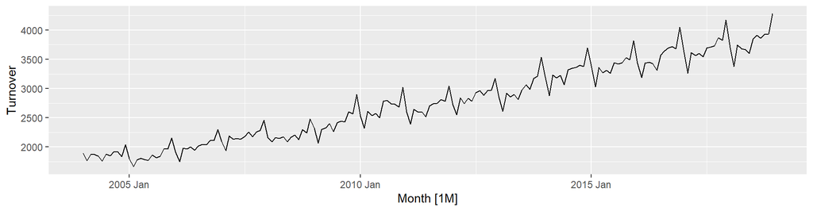

## Harmonic regression: eating-out expenditure (1/7)

```r
fit <- aus_cafe |>
  model(
    K1 = TSLM(log(Turnover) ~ trend() + fourier(K = 1)),
    K2 = TSLM(log(Turnover) ~ trend() + fourier(K = 2)),
    K3 = TSLM(log(Turnover) ~ trend() + fourier(K = 3)),
    K4 = TSLM(log(Turnover) ~ trend() + fourier(K = 4)),
    K5 = TSLM(log(Turnover) ~ trend() + fourier(K = 5)),
    K6 = TSLM(log(Turnover) ~ trend() + fourier(K = 6))
  )
```

## Harmonic regression: eating-out expenditure (2/7)

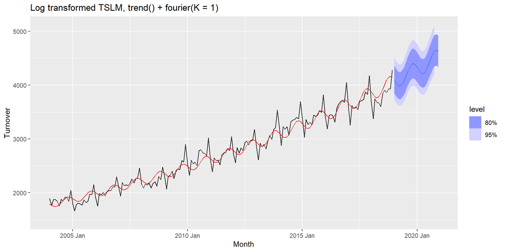

## Harmonic regression: eating-out expenditure (3/7)

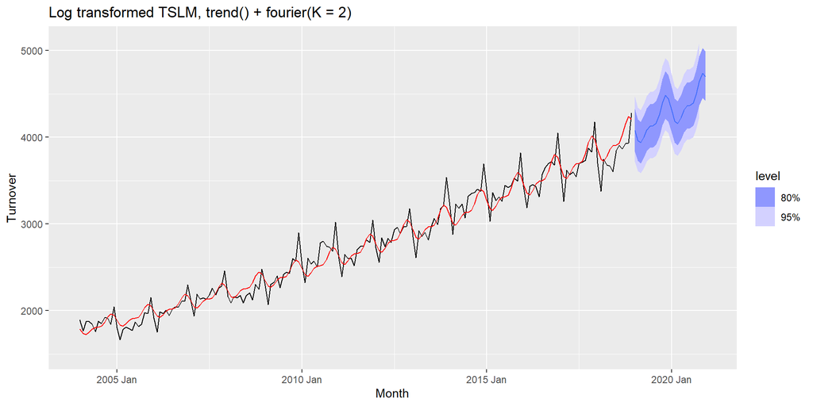

## Harmonic regression: eating-out expenditure (4/7)

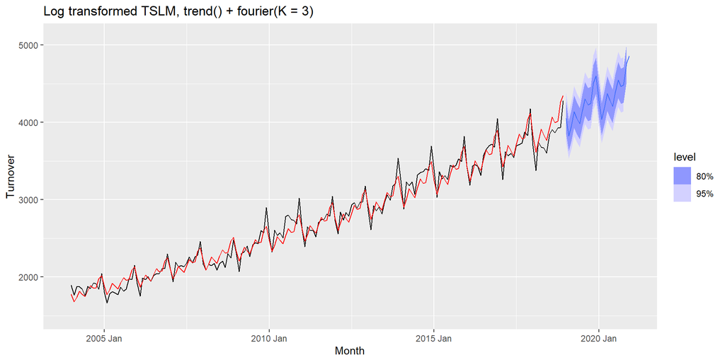

## Harmonic regression: eating-out expenditure (5/7)

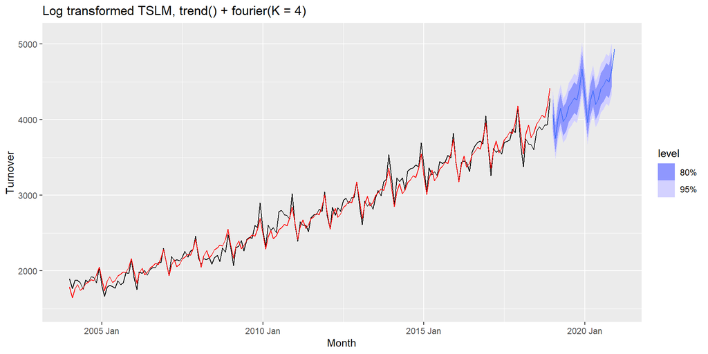

## Harmonic regression: eating-out expenditure (6/7)

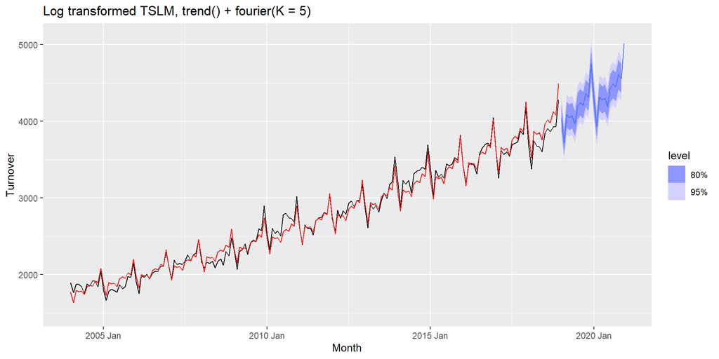

## Harmonic regression: eating-out expenditure (7/7)

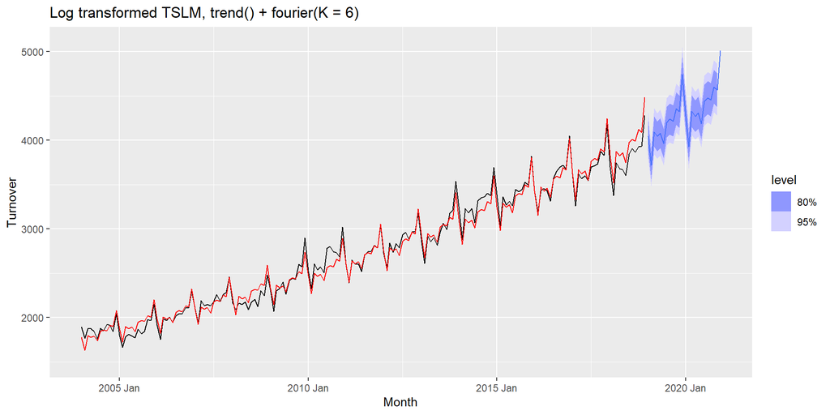

## Fourier series

Periodic seasonality can be handled using pairs of Fourier terms:
$$s_{k}(t) = \sin\left(\frac{2\pi k t}{m}\right)\qquad c_{k}(t) = \cos\left(\frac{2\pi k t}{m}\right)$$
$$y_t = a + bt + \sum_{k=1}^K \left[\alpha_k s_k(t) + \beta_k c_k(t)\right] + \varepsilon_t$$

- Every periodic function can be approximated by sums of sin and cos terms for large enough $K$.
- $K \le m/2$
- $m$ can be non-integer
- Particularly useful for large $m$.

## Comparing regression models

Computer output for regression will always give the $R^2$ value. This is a useful summary of the model.

- It is equal to the square of the correlation between $y$ and $\hat y$.
- It is often called the “coefficient of determination”.
- It can also be calculated as follows:

$$R^2 = \frac{\sum(\hat{y}_t - \bar{y})^2}{\sum(y_t-\bar{y})^2}$$

- It is the proportion of variance accounted for (explained) by the predictors.

## Comparing regression models

However …

- $R^2$ does not allow for “degrees of freedom”.
- Adding *any* variable tends to increase the value of $R^2$, even if that variable is irrelevant.

To overcome this problem, we can use *adjusted $R^2$*:

$$\bar{R}^2 = 1-(1-R^2)\frac{T-1}{T-k-1}$$

where $k=$ no. predictors and $T=$ no. observations.

**Note**

Maximizing $\bar{R}^2$ is equivalent to minimizing $\hat\sigma^2$.

$$\hat{\sigma}^2 = \frac{1}{T-k-1}\sum_{t=1}^T \varepsilon_t^2$$

## Akaike’s Information Criterion

$$\text{AIC} = -2\log(L) + 2(k+2)$$

where $L$ is the likelihood and $k$ is the number of predictors in the model.

- AIC penalizes terms more heavily than $\bar{R}^2$.
- Minimizing the AIC is asymptotically equivalent to minimizing MSE via **leave-one-out cross-validation** (for any linear regression).

## Corrected AIC

For small values of $T$, the AIC tends to select too many predictors, and so a bias-corrected version of the AIC has been developed.

$$\text{AIC}_{\text{C}} = \text{AIC} + \frac{2(k+2)(k+3)}{T-k-3}$$

As with the AIC, the AIC$_{\text{C}}$ should be minimized.

## Bayesian Information Criterion

$$\text{BIC} = -2\log(L) + (k+2)\log(T)$$

where $L$ is the likelihood and $k$ is the number of predictors in the model.

- BIC penalizes terms more heavily than AIC
- Also called SBIC and SC.
- Minimizing BIC is asymptotically equivalent to leave-$v$-out cross-validation when $v = T[1-1/(log(T)-1)]$.

## Harmonic regression: eating-out expenditure again (1/8)

```r
aus_cafe <- aus_retail |>
  filter(Industry == "Cafes, restaurants and takeaway food services",
         year(Month) %in% 2004:2018) |>
  summarise(Turnover = sum(Turnover))
aus_cafe |> autoplot(Turnover)
```

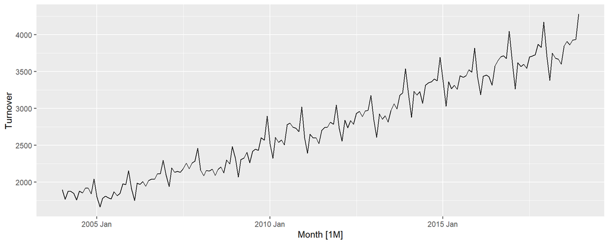

## Harmonic regression: eating-out expenditure again (2/8)

```r
fit <- aus_cafe |>
  model(
    K1 = TSLM(log(Turnover) ~ trend() + fourier(K = 1)),
    K2 = TSLM(log(Turnover) ~ trend() + fourier(K = 2)),
    K3 = TSLM(log(Turnover) ~ trend() + fourier(K = 3)),
    K4 = TSLM(log(Turnover) ~ trend() + fourier(K = 4)),
    K5 = TSLM(log(Turnover) ~ trend() + fourier(K = 5)),
    K6 = TSLM(log(Turnover) ~ trend() + fourier(K = 6))
  )
glance(fit) |> select(.model, r_squared, adj_r_squared, CV, AICc)
```

```
# A tibble: 6 × 5
  .model r_squared adj_r_squared      CV   AICc
  <chr>      <dbl>         <dbl>   <dbl>  <dbl>
1 K1         0.962         0.962 0.00238 -1085.
2 K2         0.966         0.965 0.00220 -1099.
3 K3         0.976         0.975 0.00157 -1160.
4 K4         0.980         0.979 0.00138 -1183.
5 K5         0.985         0.984 0.00104 -1234.
6 K6         0.985         0.984 0.00105 -1232.
```

## Harmonic regression: eating-out expenditure again (3/8)

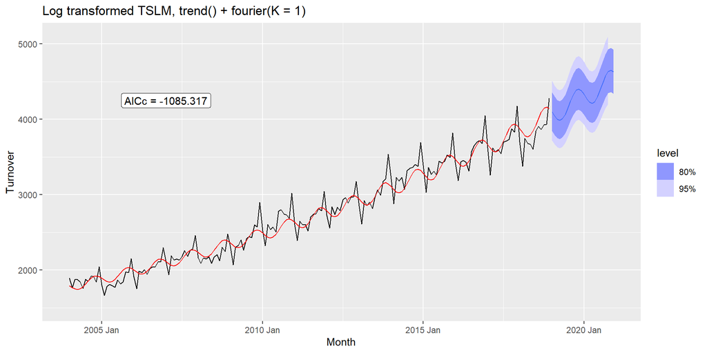

## Harmonic regression: eating-out expenditure again (4/8)

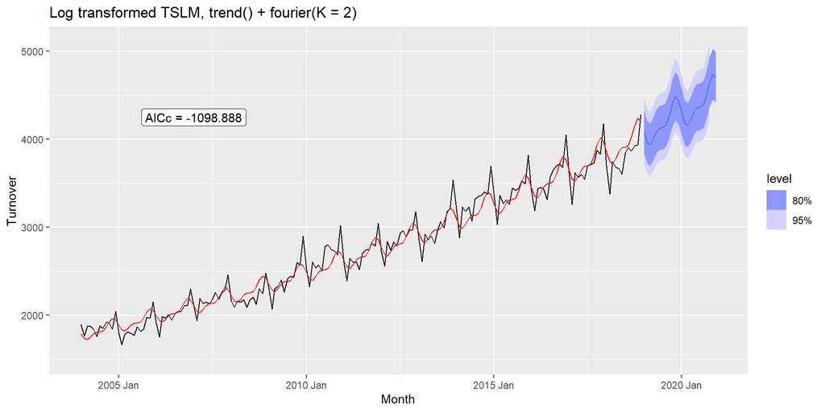

## Harmonic regression: eating-out expenditure again (5/8)

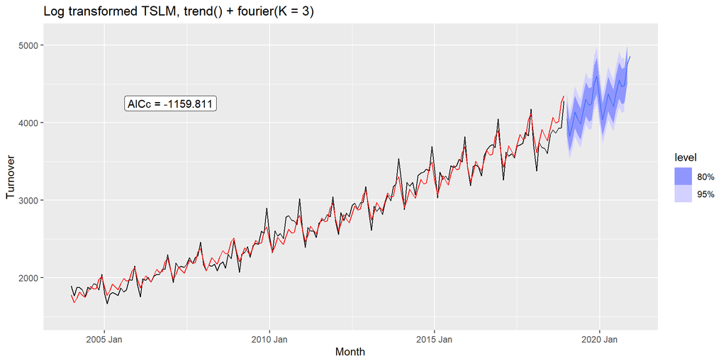

## Harmonic regression: eating-out expenditure again (6/8)

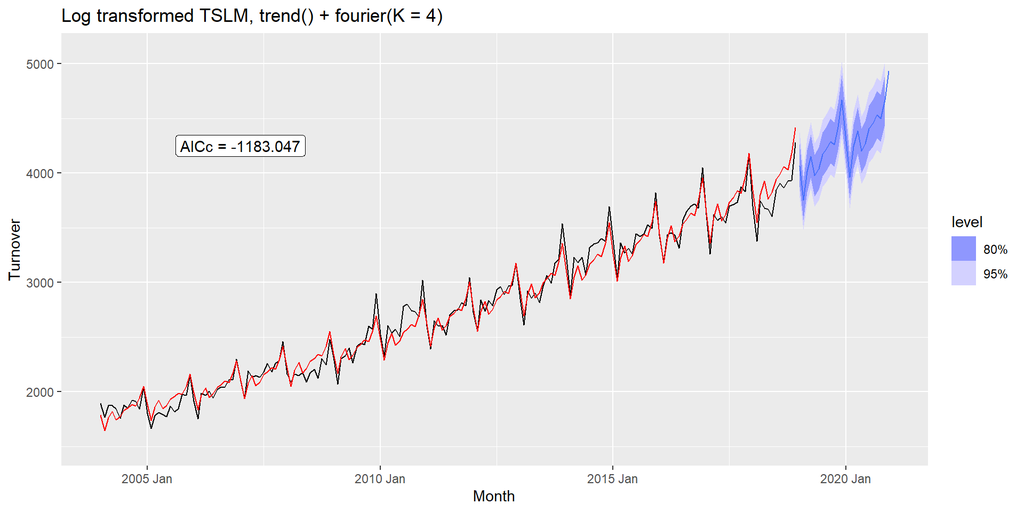

## Harmonic regression: eating-out expenditure again (7/8)

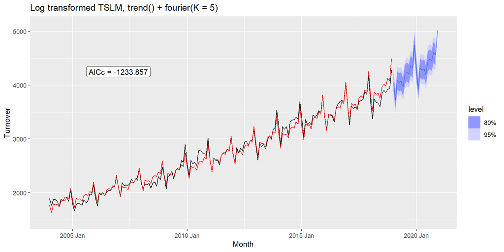

## Harmonic regression: eating-out expenditure again (8/8)

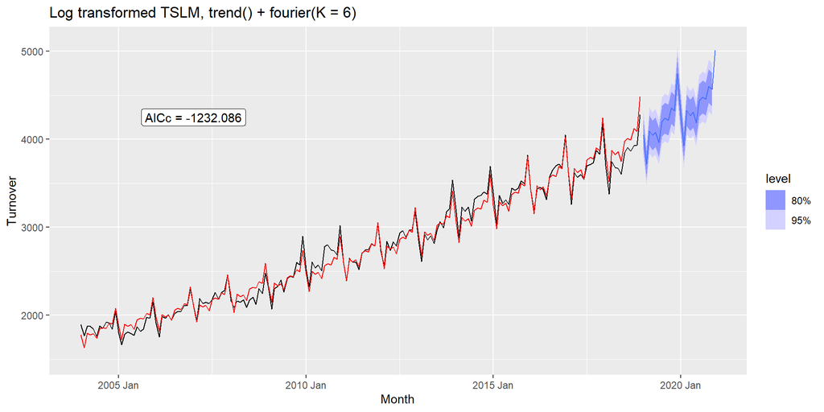

## Ex-ante versus ex-post forecasts

- **Ex ante forecasts** are made using only information available in advance.
  - require forecasts of predictors
- **Ex post forecasts** are made using later information on the predictors.
  - useful for studying behavior of forecasting models.
- trend, seasonal and calendar variables are all known in advance, so these don’t need to be forecast.

## Beer production

```r
recent_production <- aus_production |> filter(year(Quarter) >= 1992)
recent_production |> model(TSLM(Beer ~ trend() + season())) |>
   forecast() |> autoplot(recent_production)
```

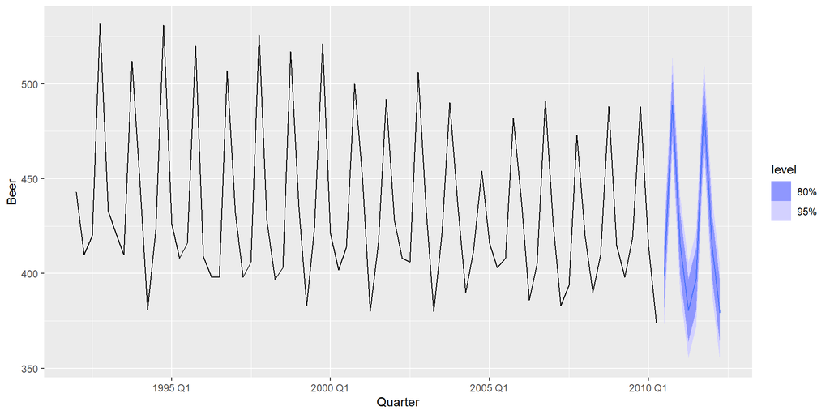

## Scenario based forecasting

- Assumes possible scenarios for the predictor variables
- Prediction intervals for scenario based forecasts do not include the uncertainty associated with the future values of the predictor variables.

## US Consumption

```r
fit_consBest <- us_change |>
  model(
    TSLM(Consumption ~ Income + Savings + Unemployment)
  )

future_scenarios <- scenarios(
  Increase = new_data(us_change, 4) |>
    mutate(Income = 1, Savings = 0.5, Unemployment = 0),
  Decrease = new_data(us_change, 4) |>
    mutate(Income = -1, Savings = -0.5, Unemployment = 0),
  names_to = "Scenario"
)

fc <- forecast(fit_consBest, new_data = future_scenarios)
```

## US Consumption

```r
us_change |> autoplot(Consumption) +
  labs(y = "% change in US consumption") +
  autolayer(fc) +
  labs(title = "US consumption", y = "% change")
```

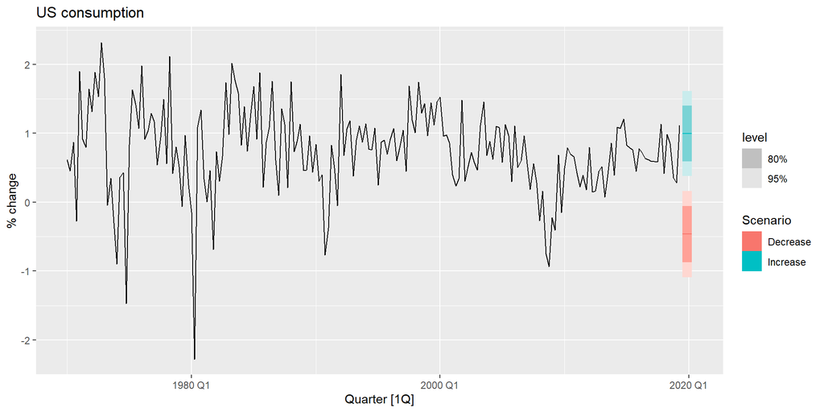

## Building a predictive regression model

- If getting forecasts of predictors is difficult, you can use lagged predictors instead.

$$y_{t+h}=\beta_0+\beta_1x_{1,t}+\dots+\beta_kx_{k,t}+\varepsilon_{t+h}$$

- A different model for each forecast horizon $h$.

## Nonlinear regression

A **log-log** functional form

$$\log y=\beta_0+\beta_1 \log x +\varepsilon$$

where $\beta_1$ is interpreted as an elasticity (the average percentage change in $y$ resulting from a $1\%$ increase in $x$).

- alternative specifications: log-linear, linear-log.
- use $\log(x+1)$ if required.

## Piecewise linear and regression splines (1/2)

$$y=f(x) +\varepsilon$$
where $f$ is a non-linear function.

- For **piecewise linear** let $x_1=x$ and

$$\begin{align*}
x_{2} = (x-c)_+ &= \left\{
\begin{array}{ll}
0 & \text{if } x < c\\
x-c & \text{if } x \ge c.
\end{array}\right.
\end{align*}$$

## Piecewise linear and regression splines (2/2)

- In general, **Linear Regression Splines**

$$x_1=x~~~x_2=(x-c_1)_+~~~\ldots~~~x_k=(x-c_{k-1})_+$$

where $c_1,\ldots,c_{k-1}$ are knots.

- Need to select knots: can be difficult and arbitrary.
- Automatic knot selection algorithms very slow.
- Using piecewise cubics achieves a smoother result.

**Warning**

Better fit but forecasting outside the range of the historical data is even more unreliable.

## Nonlinear trends

Piecewise linear trend with bend at $\tau$

$$\begin{align*}
x_{1,t} &= t \\
x_{2,t} &= \left\{ \begin{array}{ll}
0 & t <\tau\\
(t-\tau) & t \ge \tau
\end{array}\right.
\end{align*}$$

Quadratic or higher order trend

$$x_{1,t} =t,\quad x_{2,t}=t^2,\quad \dots$$

**Warning**

NOT RECOMMENDED

## Example: Boston marathon winning times (1/4)

```r
marathon <- boston_marathon |>
  filter(Event == "Men's open division") |>
  select(-Event) |>
  mutate(Minutes = as.numeric(Time) / 60)
marathon |> autoplot(Minutes) + labs(y = "Winning times in minutes")
```

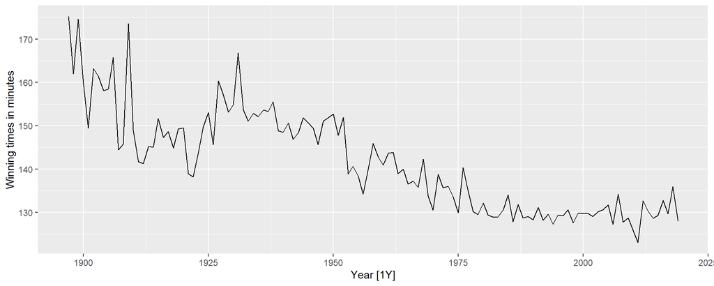

## Example: Boston marathon winning times (2/4)

```r
fit_trends <- marathon |>
  model(
    # Linear trend
    linear = TSLM(Minutes ~ trend()),
    # Exponential trend
    exponential = TSLM(log(Minutes) ~ trend()),
    # Piecewise linear trend
    piecewise = TSLM(Minutes ~ trend(knots = c(1940, 1980)))
  )
```

```r
fit_trends
```

```
# A mable: 1 x 3
   linear exponential piecewise
  <model>     <model>   <model>
1  <TSLM>      <TSLM>    <TSLM>
```

## Example: Boston marathon winning times (3/4)

```r
fit_trends |>
  forecast(h = 10) |>
  autoplot(marathon)
```

- Code
- Plot

```r
fc_trends <- fit_trends |> forecast(h = 10)
marathon |>
  autoplot(Minutes) +
  geom_line(
    data = fitted(fit_trends),
    aes(y = .fitted, colour = .model)
  ) +
  autolayer(fc_trends, alpha = 0.5, level = 95) +
  labs(
    y = "Minutes",
    title = "Boston marathon winning times"
  )
```

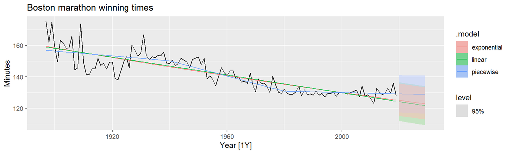

## Example: Boston marathon winning times (4/4)

```r
fit_trends |>
  select(piecewise) |>
  gg_tsresiduals()
```

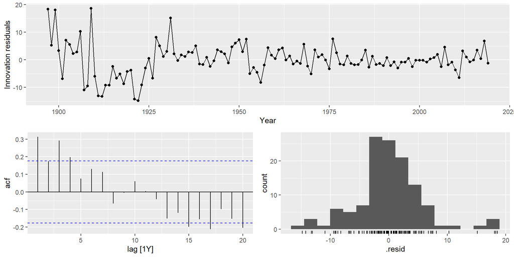

## Correlation is not causation

- When $x$ is useful for predicting $y$, it is not necessarily causing $y$.
- e.g., predict number of swimmers $y$ using number of ice-creams sold $x$.
- Correlations are useful for forecasting, even when there is no causality.
- Better models usually involve causal relationships (e.g., temperature $x$ and people $z$ to predict swimmers $y$).

## Multicollinearity

In regression analysis, multicollinearity occurs when:

- Two predictors are highly correlated (i.e., the correlation between them is close to $\pm1$).
- A linear combination of some of the predictors is highly correlated with another predictor.
- A linear combination of one subset of predictors is highly correlated with a linear combination of another subset of predictors.

## Multicollinearity

If multicollinearity exists

- the numerical estimates of coefficients may be wrong (worse in Excel than in a statistics package)
- don’t rely on the $p$-values to determine significance.
- there is no problem with model *predictions* provided the predictors used for forecasting are within the range used for fitting.
- omitting variables can help.
- combining variables can help.